# caria_stefano_11_82_204

#PLS

```r
plsr_model <- plsr(as.numeric(Cfidelity)~., data = dati2 ,
                   subset = train,
                   scale = TRUE,
                   validation = "CV")




summary(plsr_model)
```

```
Data:   X dimension: 15998 24
    Y dimension: 15998 1
Fit method: kernelpls
Number of components considered: 24

VALIDATION: RMSEP
Cross-validated using 10 random segments.
       (Intercept)  1 comps  2 comps  3 comps  4 comps  5 comps  6 comps  7 comps  8 comps  9 comps  10 comps  11 comps
CV          0.4746   0.2967   0.2846   0.2797   0.2790   0.2785   0.2784   0.2784   0.2783   0.2783    0.2783    0.2783
adjCV       0.4746   0.2967   0.2845   0.2796   0.2789   0.2785   0.2784   0.2784   0.2783   0.2782    0.2782    0.2782
       12 comps  13 comps  14 comps  15 comps  16 comps  17 comps  18 comps  19 comps  20 comps  21 comps  22 comps  23 comps
CV       0.2782    0.2782    0.2782    0.2782    0.2782    0.2782    0.2782    0.2782    0.2782    0.2782    0.2782    0.2782
adjCV    0.2782    0.2782    0.2782    0.2782    0.2782    0.2782    0.2782    0.2782    0.2782    0.2782    0.2782    0.2782
       24 comps
CV       0.2782
adjCV    0.2782

TRAINING: % variance explained
                       1 comps  2 comps  3 comps  4 comps  5 comps  6 comps  7 comps  8 comps  9 comps  10 comps  11 comps
X                        22.04    27.03    29.35    33.60    36.67    41.46    44.03    47.06    50.97     54.49     56.55
as.numeric(Cfidelity)    60.93    64.15    65.40    65.56    65.65    65.68    65.71    65.73    65.73     65.74     65.74
                       12 comps  13 comps  14 comps  15 comps  16 comps  17 comps  18 comps  19 comps  20 comps  21 comps
X                         60.54     64.95     68.55     70.78     73.15     75.63     79.14     80.57     83.70     87.47
as.numeric(Cfidelity)     65.74     65.74     65.74     65.74     65.74     65.74     65.74     65.74     65.74     65.74
                       22 comps  23 comps  24 comps
X                         91.60     95.79    100.00
as.numeric(Cfidelity)     65.74     65.74     65.74
```

I valori 60.93 64.15 65.40 65.56 65.65 rappresentano la percentuale di variabilità spiegata per la variabile y. Rispetto al modello PCR risulta leggermente più alta.

```r
lm2<-lm(as.numeric(dati_train$Cfidelity)~plsr_model$scores[,1:10])
summary(lm2) #Adjusted R-squared:  0.657
```

```
Call:
lm(formula = as.numeric(dati_train$Cfidelity) ~ plsr_model$scores[,
    1:10])

Residuals:
     Min       1Q   Median       3Q      Max
-1.10447 -0.09221  0.01968  0.16968  1.18481

Coefficients:
                                  Estimate Std. Error t value Pr(>|t|)
(Intercept)                      1.6575197  0.0021969 754.491  < 2e-16 ***
plsr_model$scores[, 1:10]Comp 1  0.1619042  0.0009602 168.607  < 2e-16 ***
plsr_model$scores[, 1:10]Comp 2  0.0841267  0.0021710  38.750  < 2e-16 ***
plsr_model$scores[, 1:10]Comp 3  0.0790540  0.0032728  24.155  < 2e-16 ***
plsr_model$scores[, 1:10]Comp 4  0.0219615  0.0024833   8.844  < 2e-16 ***
plsr_model$scores[, 1:10]Comp 5  0.0208429  0.0032570   6.399  1.6e-10 ***
plsr_model$scores[, 1:10]Comp 6  0.0087906  0.0023858   3.685 0.000230 ***
plsr_model$scores[, 1:10]Comp 7  0.0154078  0.0040857   3.771 0.000163 ***
plsr_model$scores[, 1:10]Comp 8  0.0084104  0.0029281   2.872 0.004080 **
plsr_model$scores[, 1:10]Comp 9  0.0041540  0.0027964   1.485 0.137441
plsr_model$scores[, 1:10]Comp 10 0.0034422  0.0029972   1.148 0.250791
---
Signif. codes:  0 ‘***’ 0.001 ‘**’ 0.01 ‘*’ 0.05 ‘.’ 0.1 ‘ ’ 1

Residual standard error: 0.2779 on 15987 degrees of freedom
Multiple R-squared:  0.6574,    Adjusted R-squared:  0.6572
F-statistic:  3067 on 10 and 15987 DF,  p-value: < 2.2e-16
```

il valore dell’ Adjusted R-squared: 0.657.

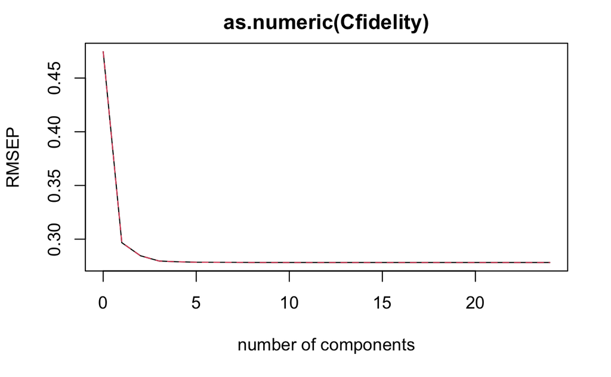

```r
validationplot(plsr_model)
```

```r
# considerando solo le prime 7 componenti...

plsr_model <- plsr(as.numeric(Cfidelity)~., ncomp = 7,
                   data = dati2,
                   subset= train,
                   scale = TRUE,
                   validation = "CV")


summary(plsr_model)# la percentuale di varianza in fedelt con 5 componenti 66.23.
```

```
Data:   X dimension: 15998 24
    Y dimension: 15998 1
Fit method: kernelpls
Number of components considered: 7

VALIDATION: RMSEP
Cross-validated using 10 random segments.
       (Intercept)  1 comps  2 comps  3 comps  4 comps  5 comps  6 comps  7 comps
CV          0.4746   0.2967   0.2845   0.2796   0.2789   0.2785   0.2784   0.2784
adjCV       0.4746   0.2967   0.2845   0.2796   0.2789   0.2785   0.2784   0.2783

TRAINING: % variance explained
                       1 comps  2 comps  3 comps  4 comps  5 comps  6 comps  7 comps
X                        22.04    27.03    29.35    33.60    36.67    41.46    44.03
as.numeric(Cfidelity)    60.93    64.15    65.40    65.56    65.65    65.68    65.71
```

```r
#Risulta più alta della percentuale spiegata col modello finale dal modello PCR
```

la percentuale di varianza in fedelt con 7 componenti 65.71. Risulta più alta della percentuale spiegata col modello finale dal modello PCR a parità di componenti principali (7)

```r
lm2<-lm(as.numeric(dati_train$Cfidelity)~plsr_model$scores[,1:7])
summary(lm2) #Adjusted R-squared:  0.657 rimane quasi invariato ma questa
```

```
Call:
lm(formula = as.numeric(dati_train$Cfidelity) ~ plsr_model$scores[,
    1:7])

Residuals:
     Min       1Q   Median       3Q      Max
-1.11150 -0.09145  0.02034  0.16783  1.19204

Coefficients:
                                Estimate Std. Error t value Pr(>|t|)
(Intercept)                    1.6575197  0.0021975 754.284  < 2e-16 ***
plsr_model$scores[, 1:7]Comp 1 0.1619042  0.0009605 168.561  < 2e-16 ***
plsr_model$scores[, 1:7]Comp 2 0.0841267  0.0021716  38.739  < 2e-16 ***
plsr_model$scores[, 1:7]Comp 3 0.0790540  0.0032737  24.148  < 2e-16 ***
plsr_model$scores[, 1:7]Comp 4 0.0219615  0.0024840   8.841  < 2e-16 ***
plsr_model$scores[, 1:7]Comp 5 0.0208429  0.0032579   6.398 1.62e-10 ***
plsr_model$scores[, 1:7]Comp 6 0.0087906  0.0023865   3.684 0.000231 ***
plsr_model$scores[, 1:7]Comp 7 0.0154078  0.0040868   3.770 0.000164 ***
---
Signif. codes:  0 ‘***’ 0.001 ‘**’ 0.01 ‘*’ 0.05 ‘.’ 0.1 ‘ ’ 1

Residual standard error: 0.2779 on 15990 degrees of freedom
Multiple R-squared:  0.6571,    Adjusted R-squared:  0.657
F-statistic:  4378 on 7 and 15990 DF,  p-value: < 2.2e-16
```

```r
#volta sono state utilizzate solamente le prime 7 componenti principali
```

Il valore di Adjusted R-squared: 0.657 rimane quasi invariato ma questa volta sono state utilizzate solamente le prime 7 componenti principali

```r
pls.pred=predict(plsr_model,x[test,],ncomp=7)


mean((pls.pred-y.test)^2) # MSE = 0.07939584
```

```
[1] 0.07930442
```

```r
table(as.numeric(dati_test$Cfidelity), round(pls.pred,0)) # 775 malclassificati su 8000. 775/8000= 0.0968 --> 9,68%
```

```
       1    2
  1 1986  700
  2   75 5239
```

# Conclusioni

Successivamente all’analisi esplorativa del dataset, si è proceduto alla creazione della variabile Cfidelity, ottenuta dalla variabile originale “Fidelity”. In seguito, si è suddiviso il dataset casualmente per 2/3 in train e per 1/3 test set. Sono stati applicati 3 modelli sul training set con i quali si è prevista la varibile Cfidelity. Il modello Lasso ha classificato erroneamente 778 osservazioni sulle 8000 del test set. Il modello creato con PCR ha classificato erroneamente 777 osservazioni. Infine il modello PLS ha classificato erroneamente 775 osservazioni del test set.